# Programming in Python for Data Science

# Final Project

## Submitted by : Aditi Jaswal

# Foreword

## This notebook will be showing some exploratory data analysis for the Disney dataset located https://data.world/kgarrett/disney-character-success-00-16. We will explore about the data and then find important questions. Later in the notebook, we will try to answer those questions using descriptive analysis

# About the dataset

## There are 5 datasets related to disney, i.e, movies, characters, revenue, directors and voice-actors. My main analysis is for disney movie dataset. Walt Disney Studios serves as the cornerstone upon which The Walt Disney Company was established. Over the years, this division has been responsible for the creation of a vast catalog of over 600 films, with its inaugural release, "Snow White and the Seven Dwarfs," dating back to 1937. While a significant number of these cinematic endeavors achieved great success, a few encountered less favorable outcomes. This notebook embarks on an exploration of a dataset encompassing Disney movies, aiming to delve into the factors that underlie the success of these cinematic productions.[website](https://goodboychan.github.io/python/datacamp/data_science/machine_learning/statistics/2020/08/23/01-Disney-Movies-and-Box-Office-Success.html)

I am going to use 3 datasets, i.e,

- **disney_movies_total_gross.csv**
- **disney-director.csv**
- **disney-voice-actor.csv**

In **disney-director.csv**, 2 columns,i.e Name(Name of the movie) and director(director of the movie) are there.

In **disney-voice-actor.csv**, 3 columns, character(character name whose voice is given), voice actor(name of the voice actor) and movie(Name of the movie)are there.

# Questions of Interest

#### In this notebook, I will be finding top 10 movies which did best business on box office, best movie from each genre. Also, I will be exploring if MPAA_rating impacted the popularity of movies or not.

# Import libraries needed for this lab

```python
# Import libraries needed for this lab
import pandas as pd
import random
import altair as alt
import string
import inspect
from hashlib import sha1
import matplotlib.pyplot as plt
```

```python
movies = pd.read_csv("data/disney_movies_total_gross.csv")
```

```python
movies.head()
```

|  | movie_title | release_date | genre | MPAA_rating | total_gross | inflation_adjusted_gross |
| --- | --- | --- | --- | --- | --- | --- |
| 0 | Snow White and the Seven Dwarfs | Dec 21, 1937 | Musical | G | $184,925,485 | $5,228,953,251 |
| 1 | Pinocchio | Feb 9, 1940 | Adventure | G | $84,300,000 | $2,188,229,052 |
| 2 | Fantasia | Nov 13, 1940 | Musical | G | $83,320,000 | $2,187,090,808 |
| 3 | Song of the South | Nov 12, 1946 | Adventure | G | $65,000,000 | $1,078,510,579 |
| 4 | Cinderella | Feb 15, 1950 | Drama | G | $85,000,000 | $920,608,730 |

```python
movies.describe()
```

|  | movie_title | release_date | genre | MPAA_rating | total_gross | inflation_adjusted_gross |
| --- | --- | --- | --- | --- | --- | --- |
| count | 579 | 579 | 562 | 523 | 579 | 579 |
| unique | 573 | 553 | 12 | 5 | 576 | 576 |
| top | The Jungle Book | Dec 25, 1997 | Comedy | PG | $0 | $0 |
| freq | 3 | 3 | 182 | 187 | 4 | 4 |

```python
movies.info()
```

```
<class 'pandas.core.frame.DataFrame'>
RangeIndex: 579 entries, 0 to 578
Data columns (total 6 columns):
 #   Column                    Non-Null Count  Dtype
---  ------                    --------------  -----
 0   movie_title               579 non-null    object
 1   release_date              579 non-null    object
 2   genre                     562 non-null    object
 3   MPAA_rating               523 non-null    object
 4   total_gross               579 non-null    object
 5   inflation_adjusted_gross  579 non-null    object
dtypes: object(6)
memory usage: 27.3+ KB
```

## Here we see that datatype of all the column is object. Lets convert them to correct datatype so we can perform analysis

```python
# Remove dollar signs and commas from the "inflation_adjusted_gross" column
movies['inflation_adjusted_gross'] = movies['inflation_adjusted_gross'].str.replace('$', '').str.replace(',', '')
```

```python
#Convert the "inflation_adjusted_gross" column to integer
movies['inflation_adjusted_gross'] = movies['inflation_adjusted_gross'].astype(int)
```

```python
movies['total_gross'] = movies['total_gross'].str.replace('$', '').str.replace(',', '')
```

```python
#Convert the "total_gross" column to integer
movies['total_gross'] = movies['total_gross'].astype(int)
```

```python
movies['release_date'] = pd.to_datetime(movies['release_date'])
```

## lets find out top 10 movies which did the best business in the market:

```python
top_movies = movies.sort_values('inflation_adjusted_gross', ascending=False)

# Display the top 10 movies
top_movies.head(10)
```

|  | movie_title | release_date | genre | MPAA_rating | total_gross | inflation_adjusted_gross |
| --- | --- | --- | --- | --- | --- | --- |
| 0 | Snow White and the Seven Dwarfs | 1937-12-21 | Musical | G | 184925485 | 5228953251 |
| 1 | Pinocchio | 1940-02-09 | Adventure | G | 84300000 | 2188229052 |
| 2 | Fantasia | 1940-11-13 | Musical | G | 83320000 | 2187090808 |
| 8 | 101 Dalmatians | 1961-01-25 | Comedy | G | 153000000 | 1362870985 |
| 6 | Lady and the Tramp | 1955-06-22 | Drama | G | 93600000 | 1236035515 |
| 3 | Song of the South | 1946-11-12 | Adventure | G | 65000000 | 1078510579 |
| 564 | Star Wars Ep. VII: The Force Awakens | 2015-12-18 | Adventure | PG-13 | 936662225 | 936662225 |
| 4 | Cinderella | 1950-02-15 | Drama | G | 85000000 | 920608730 |
| 13 | The Jungle Book | 1967-10-18 | Musical | Not Rated | 141843000 | 789612346 |
| 179 | The Lion King | 1994-06-15 | Adventure | G | 422780140 | 761640898 |

```python
genre_wise_best= movies.groupby("genre")['movie_title', 'inflation_adjusted_gross'].max()
genre_wise_best
```

| genre | movie_title | inflation_adjusted_gross |
| --- | --- | --- |
| Action | Tron | 660081224 |
| Adventure | Zootopia | 2188229052 |
| Black Comedy | The Royal Tenenbaums | 76758193 |
| Comedy | You Again | 1362870985 |
| Concert/Performance | Jonas Brothers: The 3D Concert Experi… | 76646993 |
| Documentary | X Games 3D: The Movie | 35981010 |
| Drama | crazy/beautiful | 1236035515 |
| Horror | The Puppet Masters | 48546161 |
| Musical | Tim Burton's The Nightmare Before Chr… | 5228953251 |
| Romantic Comedy | While You Were Sleeping | 356389765 |
| Thriller/Suspense | Unbreakable | 485424724 |
| Western | Tombstone | 115781734 |

## lets explore MPAA_rating column. From describe(), we can see that there are 5 unique entries for this column, i.e, PG, G, PG-13, R and Not rated. From https://en.wikipedia.org/wiki/Motion_Picture_Association_film_rating_system , PG = Parentl Guidance, G - General Audience, PG-13 = Parents Strongly Cautioned and R = Restricted.

```python
rating_counts = movies['MPAA_rating'].value_counts()
rating_counts
```

```
PG           187
PG-13        145
R            102
G             86
Not Rated      3
Name: MPAA_rating, dtype: int64
```

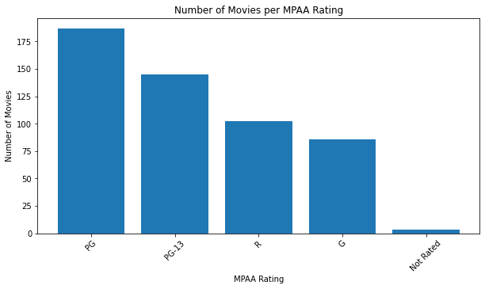

```python
plt.figure(figsize=(10, 5))
plt.bar(rating_counts.index, rating_counts)
plt.title('Number of Movies per MPAA Rating')
plt.xlabel('MPAA Rating')
plt.ylabel('Number of Movies')
plt.xticks(rotation=45)
plt.show()
```

## Lets find out if there is any trend between the ,MP rating and business done by disney movies:

```python
average_gross = movies.groupby('MPAA_rating')['inflation_adjusted_gross'].mean()
```

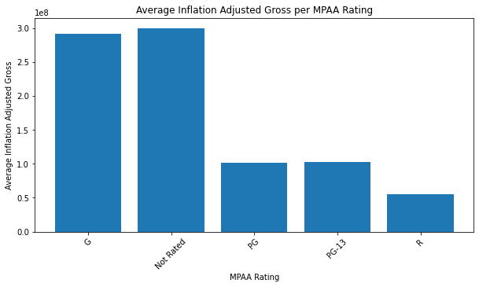

```python
plt.figure(figsize=(10, 5))
plt.bar(average_gross.index, average_gross)
plt.title('Average Inflation Adjusted Gross per MPAA Rating')
plt.xlabel('MPAA Rating')
plt.ylabel('Average Inflation Adjusted Gross')
plt.xticks(rotation=45)
plt.show()
```

## here we found out that although least number of movies were 'not rated' but those movies did maximum of the business.However, movies made for general audiences also did good business.

## From the above stats, it seems that some genre are more polpular than others. lets find out movie genre trend

```python
## finding release year from release date column
movies['release_year'] = movies['release_date'].dt.year
```

```python
# Group the movies data by 'genre' and 'release_year', and compute the mean 'adjusted_gross' for each group
grouped_movies = movies.groupby(['genre', 'release_year'])['inflation_adjusted_gross'].mean().reset_index()

# Display the first 10 rows of the grouped_movies DataFrame
print(grouped_movies.head(10))
```

```
    genre  release_year  inflation_adjusted_gross
0  Action          1981                       0.0
1  Action          1982                77184895.0
2  Action          1988                36053517.0
3  Action          1990               118358772.0
4  Action          1991                57918572.5
5  Action          1992                58965304.0
6  Action          1993                44682157.0
7  Action          1994                39545796.0
8  Action          1995               122162426.5
9  Action          1996               257755262.5
```

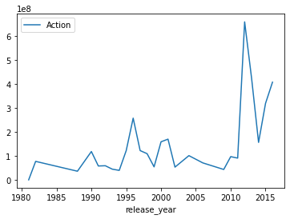

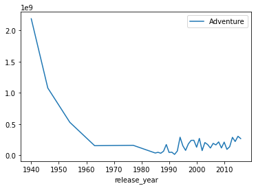

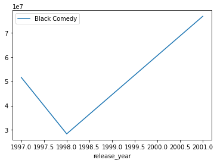

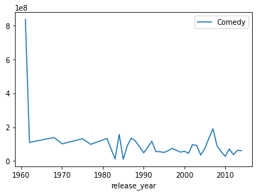

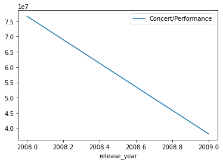

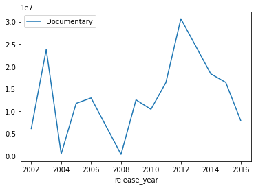

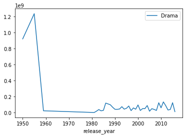

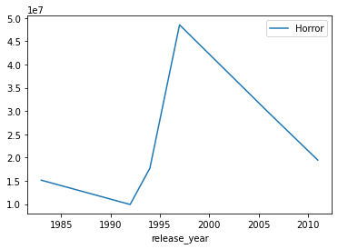

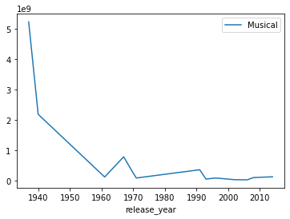

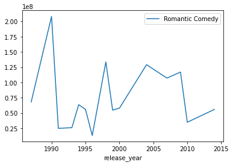

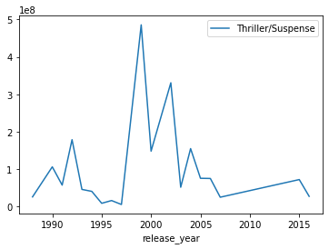

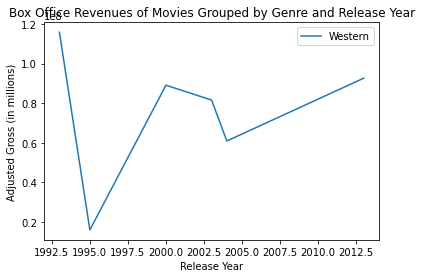

```python
# Create a plot for the genre with the highest mean adjusted gross in each year
plt.figure(figsize=(12, 6))
for genre, df in grouped_movies.groupby('genre'):
    df.plot(x='release_year', y='inflation_adjusted_gross', label=genre)
plt.title('Box Office Revenues of Movies Grouped by Genre and Release Year')
plt.xlabel('Release Year')
plt.ylabel('Adjusted Gross (in millions)')
plt.legend()
plt.show()
```

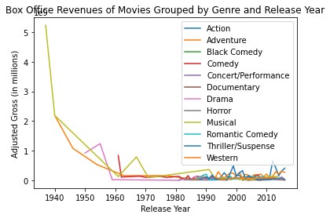

```python
grouped_data = grouped_movies.groupby('genre')

# Plot the data
for genre, genre_data in grouped_data:
    plt.plot(genre_data['release_year'], genre_data['inflation_adjusted_gross'], label=genre)

# Set up the plot
plt.title('Box Office Revenues of Movies Grouped by Genre and Release Year')
plt.xlabel('Release Year')
plt.ylabel('Adjusted Gross (in millions)')
plt.legend()
plt.show()
```

## From the above line plot, we can see that action genre was growing the fastest. However musical dropped significantly. Thus, disney's movie genre were changing in terms of popularity over the period of time

## lets explore other 2 datasets now

```python
director = pd.read_csv("data/disney-director.csv")
```

```python
director
```

|  | name | director |
| --- | --- | --- |
| 0 | Snow White and the Seven Dwarfs | David Hand |
| 1 | Pinocchio | Ben Sharpsteen |
| 2 | Fantasia | full credits |
| 3 | Dumbo | Ben Sharpsteen |
| 4 | Bambi | David Hand |
| 5 | Saludos Amigos | Jack Kinney |
| 6 | The Three Caballeros | Norman Ferguson |
| 7 | Make Mine Music | Jack Kinney |
| 8 | Fun and Fancy Free | Jack Kinney |
| 9 | Melody Time | Clyde Geronimi |
| 10 | The Adventures of Ichabod and Mr. Toad | Jack Kinney |
| 11 | Cinderella | Wilfred Jackson |
| 12 | Alice in Wonderland | Clyde Geronimi |
| 13 | Peter Pan | Hamilton Luske |
| 14 | Lady and the Tramp | Hamilton Luske |
| 15 | Sleeping Beauty | Clyde Geronimi |
| 16 | 101 Dalmatians | Wolfgang Reitherman |
| 17 | The Sword in the Stone | Wolfgang Reitherman |
| 18 | The Jungle Book | Wolfgang Reitherman |
| 19 | The Aristocats | Wolfgang Reitherman |
| 20 | Robin Hood | Wolfgang Reitherman |
| 21 | The Many Adventures of Winnie the Pooh | Wolfgang Reitherman |
| 22 | The Rescuers | Wolfgang Reitherman |
| 23 | The Fox and the Hound | Art Stevens |
| 24 | The Black Cauldron | Ted Berman |
| 25 | The Great Mouse Detective | Ron Clements |
| 26 | Oliver & Company | George Scribner |
| 27 | The Little Mermaid | Ron Clements |
| 28 | The Rescuers Down Under | Mike Gabriel |
| 29 | Beauty and the Beast | Gary Trousdale |
| 30 | Aladdin | Ron Clements |
| 31 | The Lion King | Roger Allers |
| 32 | Pocahontas | Mike Gabriel |
| 33 | The Hunchback of Notre Dame | Gary Trousdale |
| 34 | Hercules | Ron Clements |
| 35 | Mulan | Barry Cook |
| 36 | Tarzan | Chris Buck |
| 37 | Fantasia 2000 | full credits |
| 38 | Dinosaur | Ralph Zondag |
| 39 | The Emperor's New Groove | Mark Dindal |
| 40 | Atlantis: The Lost Empire | Gary Trousdale |
| 41 | Lilo & Stitch | Chris Sanders |
| 42 | Treasure Planet | Ron Clements |
| 43 | Brother Bear | Robert Walker |
| 44 | Home on the Range | Will Finn |
| 45 | Chicken Little | Mark Dindal |
| 46 | Meet the Robinsons | Stephen J. Anderson |
| 47 | Bolt | Chris Williams |
| 48 | The Princess and the Frog | Ron Clements |
| 49 | Tangled | Nathan Greno |
| 50 | Winnie the Pooh | Stephen J. Anderson |
| 51 | Wreck-It Ralph | Rich Moore |
| 52 | Frozen | Chris Buck |
| 53 | Big Hero 6 | Don Hall |
| 54 | Zootopia | Byron Howard |
| 55 | Moana | Ron Clements |

```python
voice = pd.read_csv("data/disney-voice-actors.csv")
```

```python
voice
```

|  | character | voice-actor | movie |
| --- | --- | --- | --- |
| 0 | Abby Mallard | Joan Cusack | Chicken Little |
| 1 | Abigail Gabble | Monica Evans | The Aristocats |
| 2 | Abis Mal | Jason Alexander | The Return of Jafar |
| 3 | Abu | Frank Welker | Aladdin |
| 4 | Achilles | None | The Hunchback of Notre Dame |
| ... | ... | ... | ... |
| 930 | Zeus | Rip Torn | Hercules |
| 931 | Ziggy the Vulture | Digby Wolfe | The Jungle Book |
| 932 | Zini | Max Casella | Dinosaur |
| 933 | Zipper | Corey Burton | Chip 'n Dale Rescue Rangers |
| 934 | Zira | Suzanne Pleshette | The Lion King II: Simba's Pride |

935 rows × 3 columns

## lets create a function named "merge_dataframes_inner " to merge 2 datsets and merge datasets director and voice in one dataset named voice_director

```python
def merge_dataframes_inner(df1, df2, common_column):
    """
    Merge two DataFrames using an inner join on a common column.

    Parameters
    ----------
    df1: DataFrame
      The first DataFrame to be merged.
    df2: DataFrame
      The second DataFrame to be merged.
    common_column: str
      The name of the common column to perform the inner join.

    Returns
    ----------
    merged_df: DataFrame
      The resulting DataFrame after merging the two input DataFrames using an inner join on the common column.

    Examples
    ----------

    df1 = pd.DataFrame({
    'ID': [1, 2, 3, 4],
    'Name': ['Alice', 'Bob', 'Charlie', 'David']
})

    df2 = pd.DataFrame({
    'ID': [3, 4, 5, 6],
    'Age': [25, 30, 22, 28]
})
    """
    merged_df = pd.merge(df1, df2, on=common_column, how='inner')
    return merged_df
```

```python
# Rename the 'name' column in the 'director' dataframe to 'movie' for a consistent column name
director = director.rename(columns={'name': 'movie'})

#Calling the function to merge the datasets
voice_director = merge_dataframes_inner(director, voice, 'movie')
voice_director
```

|  | movie | director | character | voice-actor |
| --- | --- | --- | --- | --- |
| 0 | Snow White and the Seven Dwarfs | David Hand | Bashful | Scotty Mattraw |
| 1 | Snow White and the Seven Dwarfs | David Hand | Doc | Roy Atwell |
| 2 | Snow White and the Seven Dwarfs | David Hand | Dopey | Eddie Collins |
| 3 | Snow White and the Seven Dwarfs | David Hand | Grumpy | Pinto Colvig |
| 4 | Snow White and the Seven Dwarfs | David Hand | Happy | Otis Harlan |
| ... | ... | ... | ... | ... |
| 637 | Moana | Ron Clements | Maui | Dwayne Johnson |
| 638 | Moana | Ron Clements | Moana Waialiki | Auli'i Cravalho |
| 639 | Moana | Ron Clements | Pua | None |
| 640 | Moana | Ron Clements | Tamatoa | Jemaine Clement |
| 641 | Moana | Ron Clements | Tui Waialiki | Temuera Morrison |

642 rows × 4 columns